# Practical Machine-Learning: Final Project

Arnon D. Lieber

July 2, 2016

**This code was written as part of the final project in the Practical Machine-learning course by Johns-hopkins University (in Coursera)**

## Background

Using devices such as Jawbone Up, Nike FuelBand, and Fitbit it is now possible to collect a large amount of data about personal activity relatively inexpensively. Here we use the data collected from accelerometers on the belt, forearm, arm, and dumbell of 6 participants. They were asked to perform barbell lifts correctly and incorrectly in 5 different ways. The goal of this assinment is to identify the way they performed the barbell lift.

```r
setwd(dir = "/Users/arnon/Documents/Arnon/Data scientist/Machine learning/Assignment4")
# rm(list=ls())

# Downloads files
#=================
# destFolder <- "Users/arnon/Documents/Arnon/Data scientist/Machine learning/Assignment4/"
# download.file(url = "https://d396qusza40orc.cloudfront.net/predmachlearn/pml-training.csv", destfile = destFolder, method = "curl")
# download.file(url = "https://d396qusza40orc.cloudfront.net/predmachlearn/pml-testing.csv", destfile = destFolder, method = "curl")
# Reads files

allData <- read.csv("/Users/arnon/Documents/Arnon/Data scientist/Machine learning/Assignment4/pml-training.csv")
test  <- read.csv("/Users/arnon/Documents/Arnon/Data scientist/Machine learning/Assignment4/pml-testing.csv")

# Shows the variables that the test dataset is missing
setdiff(colnames(allData),colnames(test))
```

```
## [1] "classe"
```

```r
# str(allData)
dim(allData)
```

```
## [1] 19622   160
```

```r
library(caret)
# Set the seed
set.seed(646)

# Partition data set for training and validation
useForTrain <- createDataPartition(allData$classe, p = .6, list = F)

predVar <- !(colnames(allData) %in% c("classe"))
trainingPred <- allData[useForTrain,predVar]
training <- allData[useForTrain,]
testingPred  <- allData[-useForTrain,predVar]
testing  <- allData[-useForTrain,]

# Assess and remove the variables that have low variability
nzv <- nearZeroVar(trainingPred)
trainingPred <- trainingPred[,-nzv]

# The X variable tell nothing about the system, let's remove it
trainingPred <- trainingPred[,-1]

# Remove variables with mainly NA (above 80%)
notNA <- apply(trainingPred, 2, function(x) {!sum(is.na(x))/dim(trainingPred)[1] > .8})
trainingPred <- trainingPred[,notNA]

rmColIndx <- grep("timestamp|X|user_name|new_window", names(trainingPred))
trainingPred <- trainingPred[, -rmColIndx]

# Define the columns of the training and testing sets
training <- training[,c("classe",colnames(trainingPred))]
testing  <- testing[,c("classe",colnames(trainingPred))]

# Confirms that the classe defines as a factor
class(allData$classe)
```

```
## [1] "factor"
```

```r
# Set the tesing set to have the same predictors as to the training
testingPred <- testingPred[,colnames(testingPred) %in% colnames(trainingPred)]

# Cross Validation building
# folds <- createFolds(y = training$classe, k = 5, list = TRUE, returnTrain = TRUE)
```

## Preproccessing

Here I aim to reduce the dimensionality using “principle components” and thereby also accelerating computation time

```r
# Reducing the complexity of the predictors by generating "principle components"
pcaObj <- preProcess(x = trainingPred, method = c("center", "scale", "pca"), thresh = 0.9)
trainPred.pre <- predict(pcaObj, trainingPred)
testPred.pre <- predict(pcaObj, testingPred)
print(pcaObj)
```

```
## Created from 11776 samples and 53 variables
##
## Pre-processing:
##   - centered (53)
##   - ignored (0)
##   - principal component signal extraction (53)
##   - scaled (53)
##
## PCA needed 21 components to capture 90 percent of the variance
```

## Modeling

#### Random forest (with PCA)

```r
# Random forest
suppressMessages(require(randomForest))

# Combining PCs with Classe
trainPCs <- data.frame(classe = training[,"classe"], trainPred.pre)

# Running random forest on the PCs elements
# mod_rf <- train(classe ~ ., data = train.pre, method="rf") #trControl=train_control
mod_rf1 <- randomForest(classe ~ ., data = trainPCs)
summary(mod_rf1)
```

```
##                 Length Class  Mode
## call                3  -none- call
## type                1  -none- character
## predicted       11776  factor numeric
## err.rate         3000  -none- numeric
## confusion          30  -none- numeric
## votes           58880  matrix numeric
## oob.times       11776  -none- numeric
## classes             5  -none- character
## importance         21  -none- numeric
## importanceSD        0  -none- NULL
## localImportance     0  -none- NULL
## proximity           0  -none- NULL
## ntree               1  -none- numeric
## mtry                1  -none- numeric
## forest             14  -none- list
## y               11776  factor numeric
## test                0  -none- NULL
## inbag               0  -none- NULL
## terms               3  terms  call
```

```r
mod_rf1
```

```
##
## Call:
##  randomForest(formula = classe ~ ., data = trainPCs)
##                Type of random forest: classification
##                      Number of trees: 500
## No. of variables tried at each split: 4
##
##         OOB estimate of  error rate: 2.75%
## Confusion matrix:
##      A    B    C    D    E class.error
## A 3310   17    6   12    3  0.01135006
## B   38 2191   46    3    1  0.03861343
## C   12   37 1984   20    1  0.03407984
## D    3    1   82 1838    6  0.04766839
## E    4    9    9   14 2129  0.01662818
```

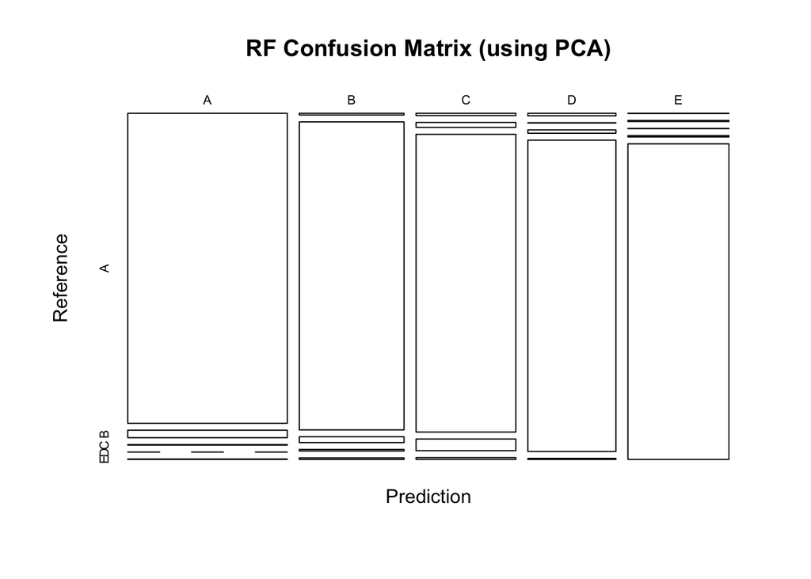

```r
# Defining data.frame with the PCs and the classe factor
testPCs <- data.frame(classe = testing$classe, testPred.pre)

# Test the model on the test data
test_rf1_pred <- predict(mod_rf1, testPCs)
confMat_rf1 <- confusionMatrix(test_rf1_pred, testing$classe)
plot(confMat_rf1$table, col = confMat_rf1$byClass,
     main = "RF Confusion Matrix (using PCA)")
```

**Figure1**: Classification using the random forest approch using PC as predictors. Graphical representation of the Confusion matrix showing the level of correct classification and errors for each category.

#### Random forest (without PCA)

```r
# Random forest
suppressMessages(require(randomForest))

# Defines train control with 5 iterations of cross validation
train_control <- trainControl(method="cv", number=5)
# getModelInfo(model = "rf")

# Running random forest on the refined data
mod_rf2 <- train(classe ~ ., data = training, method="rf", trControl=train_control)
save(file = "model.rf.cv", "mod_rf2")

summary(mod_rf2)
```

```
##                 Length Class      Mode
## call                4  -none-     call
## type                1  -none-     character
## predicted       11776  factor     numeric
## err.rate         3000  -none-     numeric
## confusion          30  -none-     numeric
## votes           58880  matrix     numeric
## oob.times       11776  -none-     numeric
## classes             5  -none-     character
## importance         53  -none-     numeric
## importanceSD        0  -none-     NULL
## localImportance     0  -none-     NULL
## proximity           0  -none-     NULL
## ntree               1  -none-     numeric
## mtry                1  -none-     numeric
## forest             14  -none-     list
## y               11776  factor     numeric
## test                0  -none-     NULL
## inbag               0  -none-     NULL
## xNames             53  -none-     character
## problemType         1  -none-     character
## tuneValue           1  data.frame list
## obsLevels           5  -none-     character
```

```r
mod_rf2$finalModel
```

```
##
## Call:
##  randomForest(x = x, y = y, mtry = param$mtry)
##                Type of random forest: classification
##                      Number of trees: 500
## No. of variables tried at each split: 27
##
##         OOB estimate of  error rate: 0.31%
## Confusion matrix:
##      A    B    C    D    E class.error
## A 3348    0    0    0    0 0.000000000
## B   13 2265    1    0    0 0.006143045
## C    0    5 2049    0    0 0.002434275
## D    0    0    9 1920    1 0.005181347
## E    0    1    0    6 2158 0.003233256
```

```r
mod_rf2
```

```
## Random Forest
##
## 11776 samples
##    53 predictor
##     5 classes: 'A', 'B', 'C', 'D', 'E'
##
## No pre-processing
## Resampling: Cross-Validated (5 fold)
## Summary of sample sizes: 9420, 9421, 9420, 9422, 9421
## Resampling results across tuning parameters:
##
##   mtry  Accuracy   Kappa
##    2    0.9909984  0.9886115
##   27    0.9956692  0.9945211
##   53    0.9948203  0.9934470
##
## Accuracy was used to select the optimal model using  the largest value.
## The final value used for the model was mtry = 27.
```

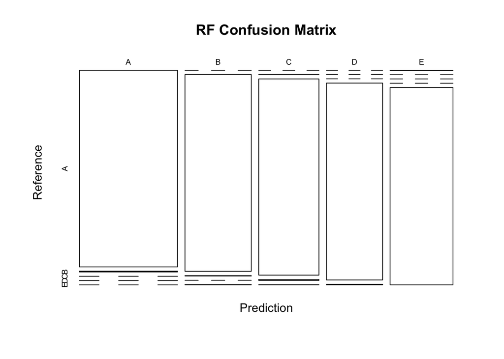

```r
# Test the model on the test data
test_rf2_pred <- predict(mod_rf2, testingPred)
confMat_rf2 <- confusionMatrix(test_rf2_pred, testing$classe)
plot(confMat_rf2$table, col = confMat_rf2$byClass, main = "RF Confusion Matrix")
```

#### Prediction with decision trees

```r
# Prediction with decision trees
suppressMessages(require(rpart))

mod_rpart <- rpart(classe ~ ., data=training, method="class")
test_rpart_pred <- predict(mod_rpart, testingPred, type = "class")
confusionMatrix(test_rpart_pred, testing$classe)
```

```
## Confusion Matrix and Statistics
##
##           Reference
## Prediction    A    B    C    D    E
##          A 2145   73    9    4    0
##          B   64 1285   89   52    0
##          C   23  150 1248  151   62
##          D    0   10   22 1030  179
##          E    0    0    0   49 1201
##
## Overall Statistics
##
##                Accuracy : 0.8806
##                  95% CI : (0.8732, 0.8877)
##     No Information Rate : 0.2845
##     P-Value [Acc > NIR] : < 2.2e-16
##
##                   Kappa : 0.849
##  Mcnemar's Test P-Value : NA
##
## Statistics by Class:
##
##                      Class: A Class: B Class: C Class: D Class: E
## Sensitivity            0.9610   0.8465   0.9123   0.8009   0.8329
## Specificity            0.9847   0.9676   0.9404   0.9678   0.9923
## Pos Pred Value         0.9615   0.8624   0.7638   0.8300   0.9608
## Neg Pred Value         0.9845   0.9633   0.9807   0.9612   0.9635
## Prevalence             0.2845   0.1935   0.1744   0.1639   0.1838
## Detection Rate         0.2734   0.1638   0.1591   0.1313   0.1531
## Detection Prevalence   0.2843   0.1899   0.2083   0.1582   0.1593
## Balanced Accuracy      0.9729   0.9071   0.9263   0.8844   0.9126
```

[figure not shown]

```r
library(rpart.plot)
library(rattle)
fancyRpartPlot(mod_rpart)
```

**Figure3**: Graphical representation of decision tree. The graph shows the partitioning to different classes, moving from the most influential predictors down with their importance.

#### Conclusions

The best prediction was achieved using the 53 predictors of the tidy training set, appling random forest (without preior PCA)

Here is the prediction of exercise class for the 20 entries in the test dataset:

```r
# Sets the test set to have the same predictors as to the training set
test <- test[,colnames(test) %in% colnames(trainingPred)]

# Apply the machine learning model to the test data set, and get the predictions
predictionOut <- predict(mod_rf2, test)
as.character(predictionOut)
```

```
##  [1] "B" "A" "B" "A" "A" "E" "D" "B" "A" "A" "B" "C" "B" "A" "E" "E" "A"
## [18] "B" "B" "B"
```

#### Out of sample error

Here we want to estimate the level of error that the model does not fit to the testing set

```r
# Accuracy of the predicted model
outOfSampleAccuracy <- sum(test_rf2_pred == testing$classe)/length(test_rf2_pred)

# Out Of Sample Error
paste0("Out of sample error: ", round((1-outOfSampleAccuracy)*100, digits = 2),"%")
```

```
## [1] "Out of sample error: 0.36%"
```